# Question

Cubing and cube rooting are inverse operations. Thus, for any value of $x$, if we apply both operations, we get back to $x$.

$$\sqrt[3]{x^3} \equiv
\left(\sqrt[3]{x}\right)^3 \equiv x$$

Because cubing and [cube-rooting](https://en.wikipedia.org/wiki/Cube_root) are inverse operations, curves $y=x^3$ and $y=\sqrt[3]{x}$ have reflective symmetry over the $y=x$ line.

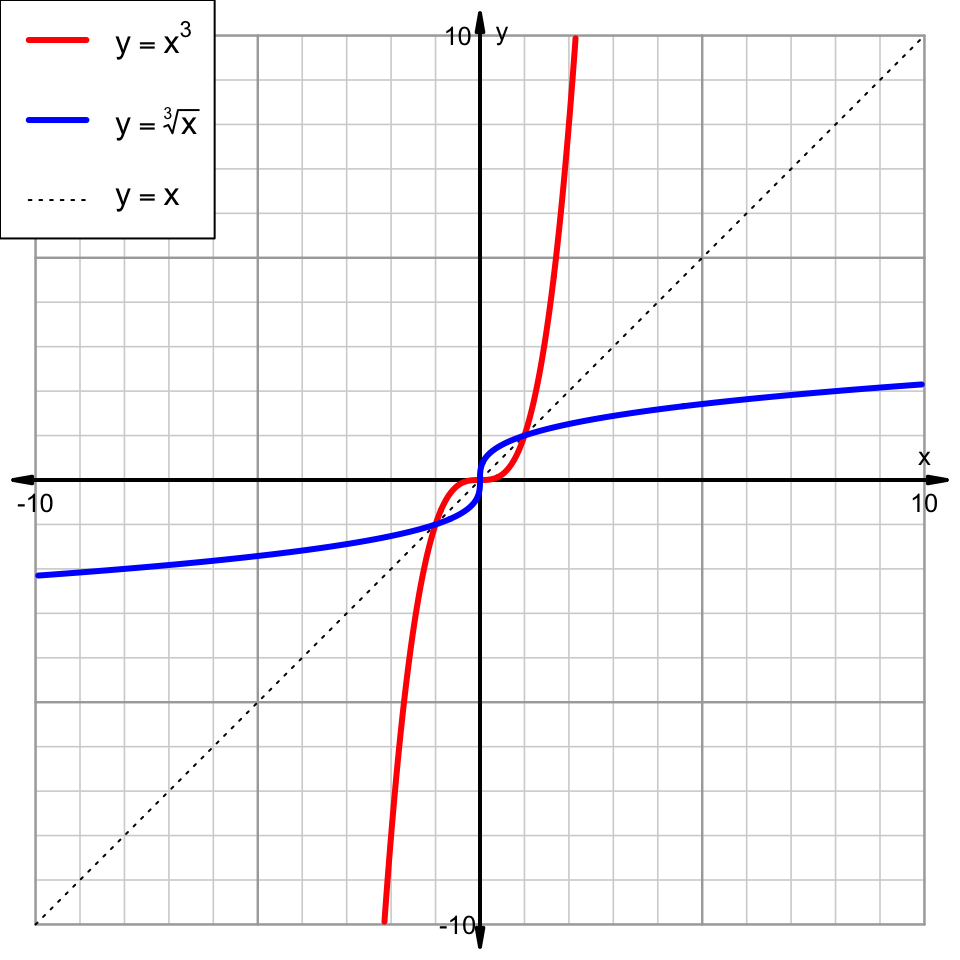

Let function $f$ be defined by translating the $y=x^3$ curve. The graph of $y~=~f(x)$ is drawn below.

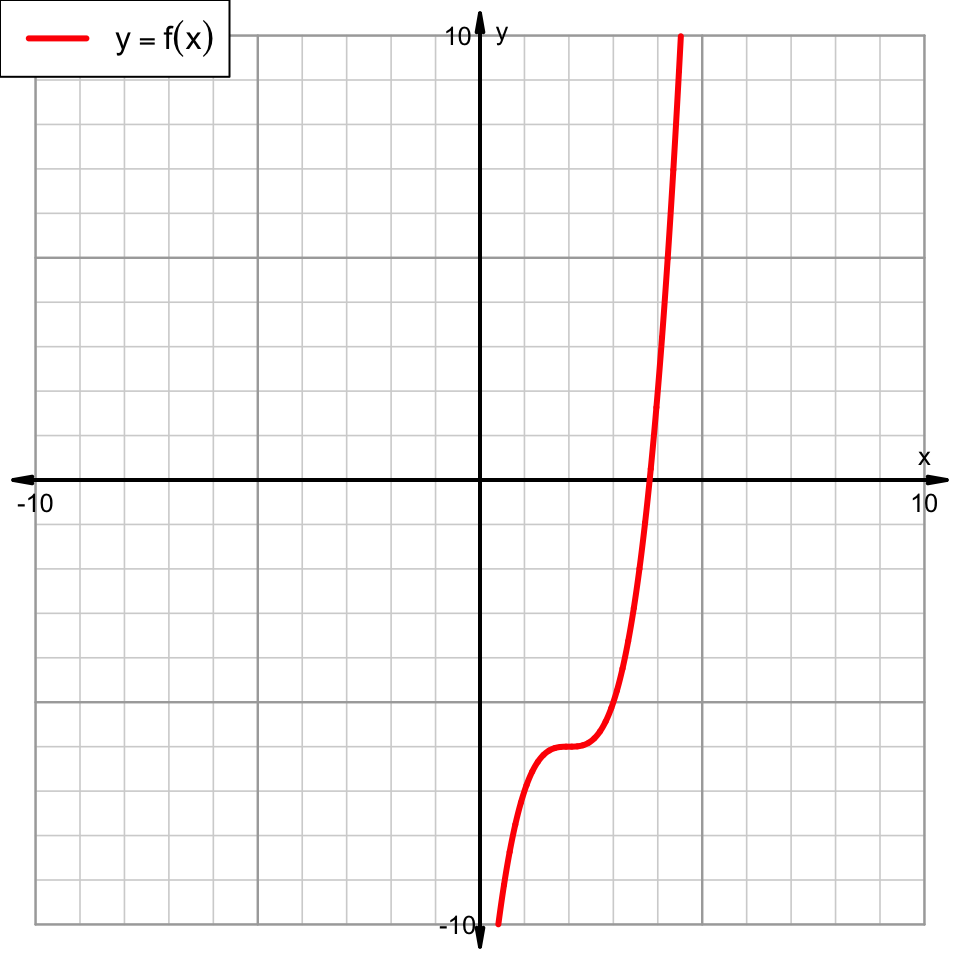

Based on the graph above, determine the values of the four parameters ($a$, $b$, $c$, and $d$) to define $f$ and its inverse $f^{-1}$ algebraically.

$$\begin{align}
f(x)~&=~(x+a)^3+b \\ \\
f^{-1}(x)~&=~\sqrt[3]{x+c}+d
\end{align}$$

- $a=$ ##ANSWER1##
- $b=$ ##ANSWER2##
- $c=$ ##ANSWER3##
- $d=$ ##ANSWER4##

## Answerlist

- -9
- -8
- -7
- -6
- -5
- -4
- -3
- -2
- -1
- 0
- 1
- 2
- 3
- 4
- 5
- 6
- 7
- 8
- 9
- -9
- -8
- -7
- -6
- -5
- -4
- -3
- -2
- -1
- 0
- 1
- 2
- 3
- 4
- 5
- 6
- 7
- 8
- 9
- -9
- -8
- -7
- -6
- -5
- -4
- -3
- -2
- -1
- 0
- 1
- 2
- 3
- 4
- 5
- 6
- 7
- 8
- 9
- -9
- -8
- -7
- -6
- -5
- -4
- -3
- -2
- -1
- 0
- 1
- 2
- 3
- 4
- 5
- 6
- 7
- 8
- 9

# Solution

To find $a$ and $b$, determine the horizontal translation and the vertical translation. The curve $y=f(x)$ has its [inflection point](https://en.wikipedia.org/wiki/Inflection_point) at $(2, -6)$. Thus,

$$f(x)~=~(x-2)^3-6$$

So,
$$a=-2$$
$$b=-6$$

To find the inverse function, first replace $x$ with $y$ and replace $f(x)$ with $x$.

$$x~=~(y-2)^3-6$$

Add 6 to both sides.

$$x+6~=~(y-2)^3$$

Take the [cube root](https://en.wikipedia.org/wiki/Cube_root) of both sides.

$$\sqrt[3]{x+6}~=~y-2$$

Add 2 to both sides.

$$\sqrt[3]{x+6}+2~=~y$$

Swap sides and replace $y$ with $f^{-1}(x)$.

$$f^{-1}(x)~=~\sqrt[3]{x+6}+2$$

So,

$$c=6$$
$$d=2$$

Notice, if you graph both curves, you’ll see they have reflectional symmetry over the $y=x$ line.

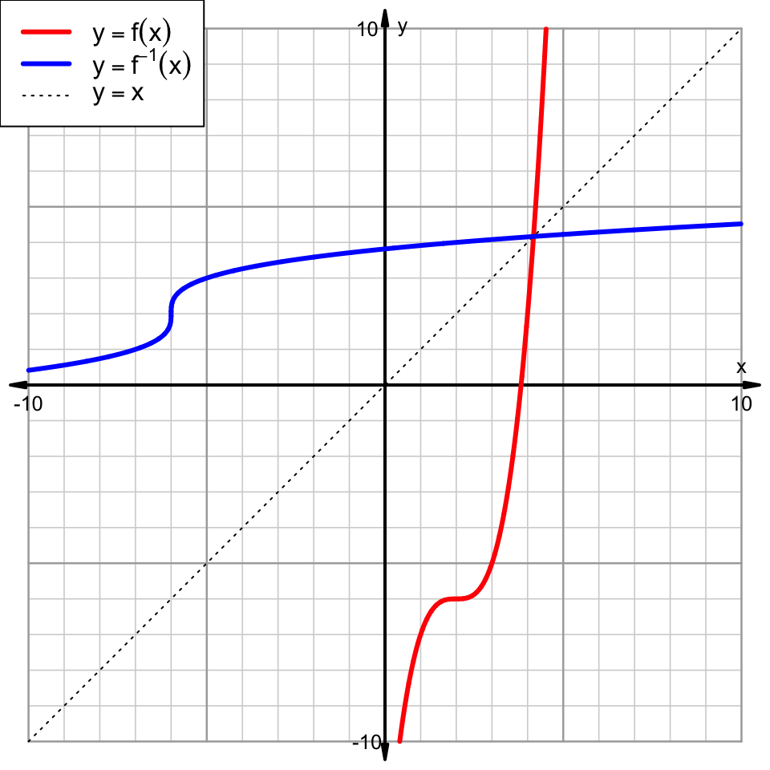

With some thinking, you might even determine a graph-based shortcut that allows you to skip that algebraic manipulation to find $c$ and $d$.

# Meta-information

extype: cloze exclozetype: schoice|schoice|schoice|schoice exsolution: 0000000100000000000|0001000000000000000|0000000000000001000|0000000000010000000 exname: inverse_cube_function